# Geospatial data analysis in R

Relating vector data

Josh Merfeld

KDI School

October 1, 2024

# Distances

## More distances

- We have points for households
- We have points for health facilities
- We can calculate the distance between each household and each health facility
  - Finding distances between points is a common GIS task!

## Distance matrix

- The name of the households data is `households.dta`
  - This is a Stata dataset
  - You can read it using the package `haven`
- Please go ahead and try loading the dataset and then turning it into a `terra` object
  - You’ll have to find the names of the columns that represent the coordinates

## Distance matrix

```r
# households
households <- read_dta("week4files/households.dta")
households <- vect(households, geom = c("ea_lon_mod", "ea_lat_mod"), crs = "EPSG:4326")
# health facilities
# do it in one line!
health <- vect(read_csv("week4files/points.csv"), geom = c("x", "y"), crs = "EPSG:4326")
```

## Distance matrix

```r
distances <- distance(households, health)
dim(households)
```

```
[1] 11290    42
```

```r
dim(health)
```

```
[1] 155   1
```

```r
dim(distances)
```

```
[1] 11290   155
```

## Distance matrix - “Heat map”

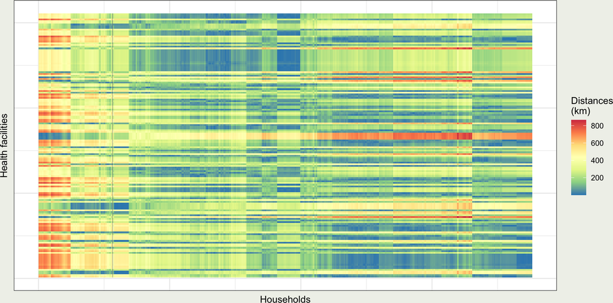

## Closest health facility by household

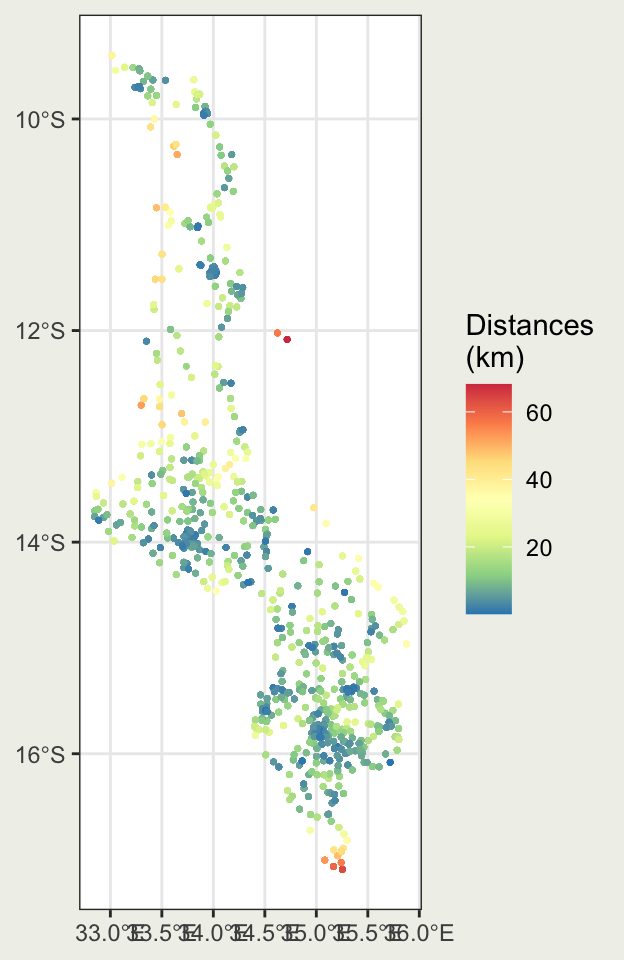

## How did I create the map?

- The `distances` object is a matrix
  - What are the rows and what are the columns?
- If we want to find the closest health facility to each household, what do we need to do?
  - We need to find the minimum distance for each row
  - Do you remember?

## Closest health facility by household

- We can use the `apply` function!
  - But with `"min"` instead of `"sum"`
  - The rows are in the same order as the households, so…

```r
distances <- distance(households, health)
closest <- apply(distances, 1, "min")

# they're in the same order!
households$closest <- closest

ggplot() +
  geom_spatvector(data = households, aes(color = closest/1000), size = 0.5) +
  scale_color_distiller("Distances\n(km)", palette = "Spectral") +
  theme_bw()
```

## Distances - points and polygons

# More advanced operations

## Let’s go over some more advanced operations

- First up:
  - Spatial overlap

## A grid in Korea - `kgrid.zip`

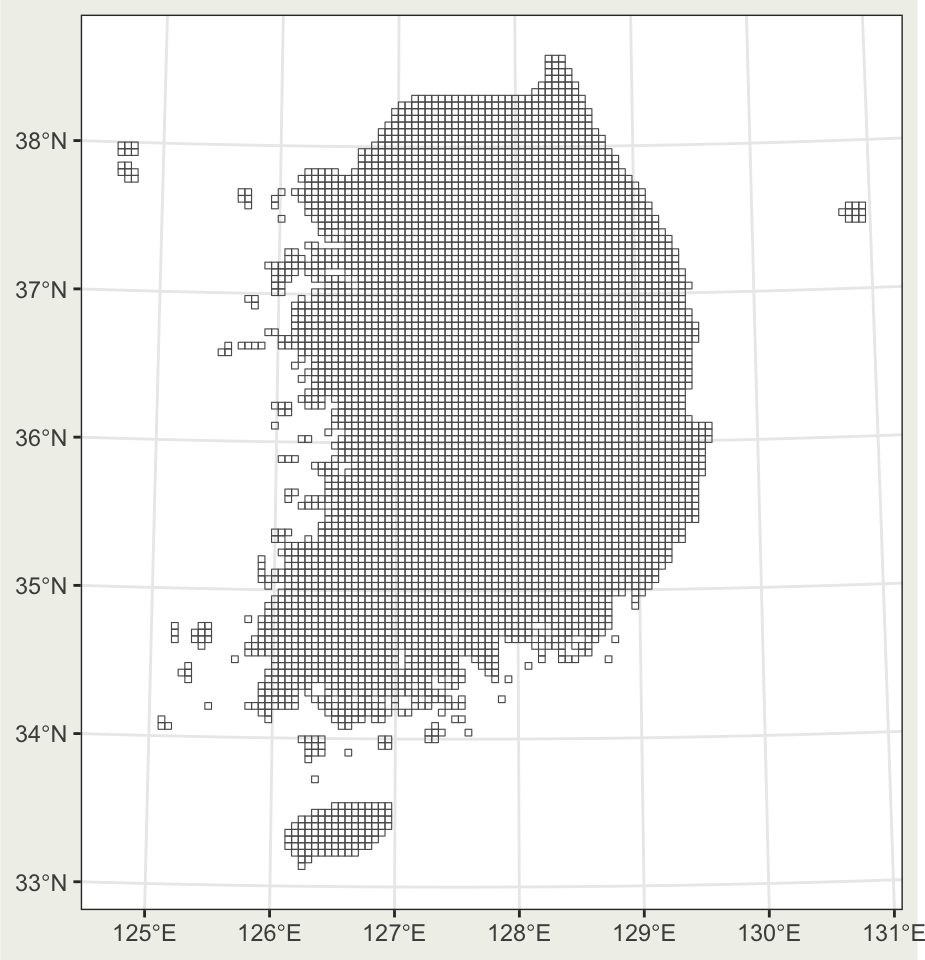

## A grid in Korea - `kgrid.zip`

- We will discuss how to make a grid after we learn about rasters
- For now, the grid is a shapefile
- A very common operation:
  - We want to know which province/city each grid cell is in
  - This isn’t straightforward. Why?
- A grid cell can overlap multiple provinces/cities

## The data

- Here is the data:
  - `kshape.shp` is the shapefile of the provinces/cities
  - `kgrid.shp` is the grid
  - I have uploaded .zip files for both

```r
kshape <- vect("week4files/kshape.shp")
kgrid <- vect("week4files/kgrid.shp")
kgrid
```

```
 class       : SpatVector
 geometry    : polygons
 dimensions  : 4906, 1  (geometries, attributes)
 extent      : 746110.3, 1306110, 1458754, 2068754  (xmin, xmax, ymin, ymax)
 source      : kgrid.shp
 coord. ref. : Korea 2000 / Unified CS (EPSG:5179)
 names       :    id
 type        : <int>
 values      :    65
                  66
                  67
```

## The `intersect` function from `terra`

- We are going to use the `intersect` function
- Here’s what it will do:
  - It will find the intersection of the grid cell and the province/city
  - Except, it will return a new feature for EACH overlap
- Let’s look at some maps

## The `intersect` function from `terra`

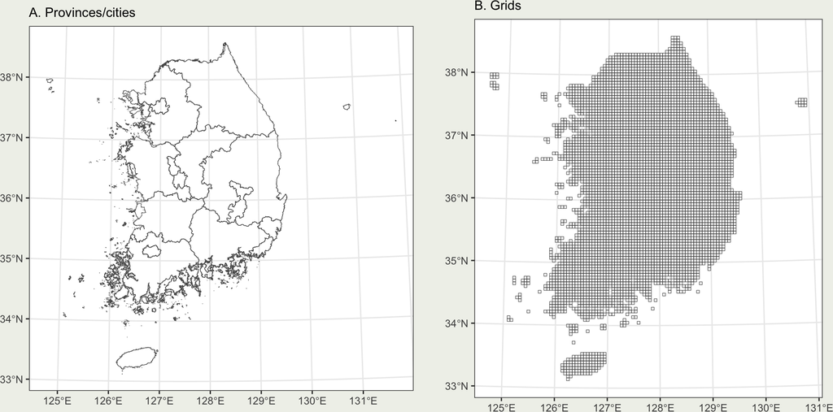

## The `intersect` function from `terra`

```r
intersection <- intersect(kgrid, kshape)
intersection
```

```
 class       : SpatVector
 geometry    : polygons
 dimensions  : 5546, 3  (geometries, attributes)
 extent      : 746110.3, 1304099, 1458754, 2068444  (xmin, xmax, ymin, ymax)
 coord. ref. : Korea 2000 / Unified CS (EPSG:5179)
 names       :    id CTPRVN_CD CTP_ENG_NM
 type        : <int>     <chr>      <chr>
 values      :    65        51 Gangwon-do
                  66        51 Gangwon-do
                  67        51 Gangwon-do
```

```r
kgrid
```

```
 class       : SpatVector
 geometry    : polygons
 dimensions  : 4906, 1  (geometries, attributes)
 extent      : 746110.3, 1306110, 1458754, 2068754  (xmin, xmax, ymin, ymax)
 source      : kgrid.shp
 coord. ref. : Korea 2000 / Unified CS (EPSG:5179)
 names       :    id
 type        : <int>
 values      :    65
                  66
                  67
```

## One grid cell, multiple overlaps

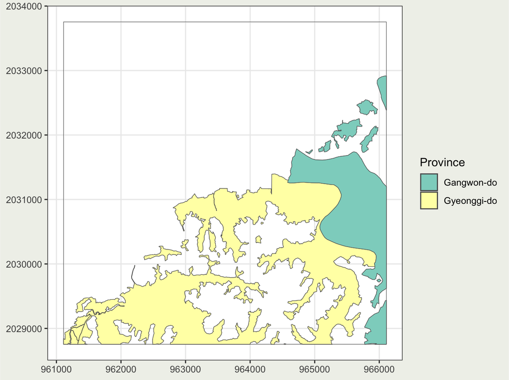

## One grid cell, multiple overlaps

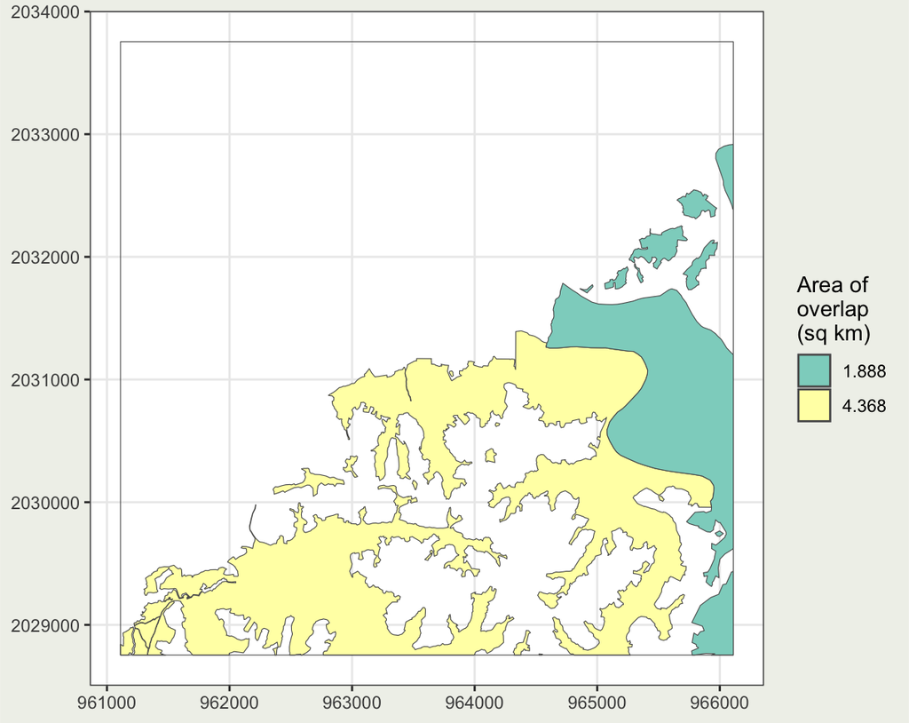

## Area of overlap

- So what do we want to do?
  - Let’s find the area of overlap for each grid cell and each province/city
  - Then let’s take the LARGEST overlap and assign that to the grid cell
  - In practice, depending on the context, you could use a weighted mean or something else
    - This won’t work with categorical variables, though

```r
# Get area of all overlaps
intersection$area <- expanse(intersection)
# turn it into a tibble
intersection <- as_tibble(intersection)
# Get the largest overlap
intersection <- intersection |> group_by(id) |> filter(area==max(area)) |> ungroup()
```

## Area of overlap

```r
intersection
```

```
# A tibble: 4,906 × 4
      id CTPRVN_CD CTP_ENG_NM      area
   <int> <chr>     <chr>          <dbl>
 1    65 51        Gangwon-do   332498.
 2    66 51        Gangwon-do  3885964.
 3    67 51        Gangwon-do  1659454.
 4   193 51        Gangwon-do   477650.
 5   194 51        Gangwon-do 12783973.
 6   195 51        Gangwon-do 14674738.
 7   321 51        Gangwon-do   289674.
 8   322 51        Gangwon-do 14274204.
 9   323 51        Gangwon-do 22582297.
10   324 51        Gangwon-do   604121.
# ℹ 4,896 more rows
```

```r
kgrid
```

```
 class       : SpatVector
 geometry    : polygons
 dimensions  : 4906, 1  (geometries, attributes)
 extent      : 746110.3, 1306110, 1458754, 2068754  (xmin, xmax, ymin, ymax)
 source      : kgrid.shp
 coord. ref. : Korea 2000 / Unified CS (EPSG:5179)
 names       :    id
 type        : <int>
 values      :    65
                  66
                  67
```

## Distances - lines in polygons